# Clustering

Bartłomiej Ramotowski

## Introduction

Objective of this project is to gain insights into the relation between sleep patterns and lifestyle factors by using clustering algorithms. Identifying clusters of individuals with similar sleep patterns and lifestyle characteristics can contribute to the development of better strategies and recommendations for improving sleep quality and overall well-being.

Link to kaggle data set: https://www.kaggle.com/datasets/uom190346a/sleep-health-and-lifestyle-dataset

Dataset Columns descriptions form Kaggle:

Person ID: An identifier for each individual.

Gender: The gender of the person (Male/Female).

Age: The age of the person in years.

Occupation: The occupation or profession of the person.

Sleep Duration (hours): The number of hours the person sleeps per day.

Quality of Sleep (scale: 1-10): A subjective rating of the quality of sleep, ranging from 1 to 10.

Physical Activity Level (minutes/day): The number of minutes the person engages in physical activity daily.

Stress Level (scale: 1-10): A subjective rating of the stress level experienced by the person, ranging from 1 to 10.

BMI Category: The BMI category of the person (e.g., Underweight, Normal, Overweight).

Blood Pressure (systolic/diastolic): The blood pressure measurement of the person, indicated as systolic pressure over diastolic pressure.

Heart Rate (bpm): The resting heart rate of the person in beats per minute. Daily Steps: The number of steps the person takes per day.

Sleep Disorder: The presence or absence of a sleep disorder in the person (None, Insomnia, Sleep Apnea).

### Reading Data

In this project at first we have to prepare and clean the data for clustering. We begin with reading the data from a CSV file, examining its structure, and summarizing key information. We also convert certain variables to the appropriate data types.

```r
health<-read.csv("Sleep_health_and_lifestyle_dataset.csv")
head(health,10)
```

```
##    Person.ID Gender Age           Occupation Sleep.Duration Quality.of.Sleep
## 1          1   Male  27    Software Engineer            6.1                6
## 2          2   Male  28               Doctor            6.2                6
## 3          3   Male  28               Doctor            6.2                6
## 4          4   Male  28 Sales Representative            5.9                4
## 5          5   Male  28 Sales Representative            5.9                4
## 6          6   Male  28    Software Engineer            5.9                4
## 7          7   Male  29              Teacher            6.3                6
## 8          8   Male  29               Doctor            7.8                7
## 9          9   Male  29               Doctor            7.8                7
## 10        10   Male  29               Doctor            7.8                7
##    Physical.Activity.Level Stress.Level BMI.Category Blood.Pressure Heart.Rate
## 1                       42            6   Overweight         126/83         77
## 2                       60            8       Normal         125/80         75
## 3                       60            8       Normal         125/80         75
```

[output cut: 18 more lines]

```r
#chcking data structure
str(health)
```

```
## 'data.frame':    374 obs. of  13 variables:
##  $ Person.ID              : int  1 2 3 4 5 6 7 8 9 10 ...
##  $ Gender                 : chr  "Male" "Male" "Male" "Male" ...
##  $ Age                    : int  27 28 28 28 28 28 29 29 29 29 ...
##  $ Occupation             : chr  "Software Engineer" "Doctor" "Doctor" "Sales Representative" ...
##  $ Sleep.Duration         : num  6.1 6.2 6.2 5.9 5.9 5.9 6.3 7.8 7.8 7.8 ...
##  $ Quality.of.Sleep       : int  6 6 6 4 4 4 6 7 7 7 ...
##  $ Physical.Activity.Level: int  42 60 60 30 30 30 40 75 75 75 ...
##  $ Stress.Level           : int  6 8 8 8 8 8 7 6 6 6 ...
##  $ BMI.Category           : chr  "Overweight" "Normal" "Normal" "Obese" ...
##  $ Blood.Pressure         : chr  "126/83" "125/80" "125/80" "140/90" ...
##  $ Heart.Rate             : int  77 75 75 85 85 85 82 70 70 70 ...
##  $ Daily.Steps            : int  4200 10000 10000 3000 3000 3000 3500 8000 8000 8000 ...
##  $ Sleep.Disorder         : chr  "None" "None" "None" "Sleep Apnea" ...
```

```r
#data summary
summary(health)
```

```
##    Person.ID         Gender               Age         Occupation
##  Min.   :  1.00   Length:374         Min.   :27.00   Length:374
##  1st Qu.: 94.25   Class :character   1st Qu.:35.25   Class :character
##  Median :187.50   Mode  :character   Median :43.00   Mode  :character
##  Mean   :187.50                      Mean   :42.18
##  3rd Qu.:280.75                      3rd Qu.:50.00
##  Max.   :374.00                      Max.   :59.00
##  Sleep.Duration  Quality.of.Sleep Physical.Activity.Level  Stress.Level
##  Min.   :5.800   Min.   :4.000    Min.   :30.00           Min.   :3.000
##  1st Qu.:6.400   1st Qu.:6.000    1st Qu.:45.00           1st Qu.:4.000
##  Median :7.200   Median :7.000    Median :60.00           Median :5.000
##  Mean   :7.132   Mean   :7.313    Mean   :59.17           Mean   :5.385
##  3rd Qu.:7.800   3rd Qu.:8.000    3rd Qu.:75.00           3rd Qu.:7.000
##  Max.   :8.500   Max.   :9.000    Max.   :90.00           Max.   :8.000
##  BMI.Category       Blood.Pressure       Heart.Rate     Daily.Steps
##  Length:374         Length:374         Min.   :65.00   Min.   : 3000
##  Class :character   Class :character   1st Qu.:68.00   1st Qu.: 5600
##  Mode  :character   Mode  :character   Median :70.00   Median : 7000
##                                        Mean   :70.17   Mean   : 6817
##                                        3rd Qu.:72.00   3rd Qu.: 8000
##                                        Max.   :86.00   Max.   :10000
##  Sleep.Disorder
##  Length:374
##  Class :character
##  Mode  :character
##
##
##
```

```r
#checking data for null values
health<-health[complete.cases(health), ]
```

```r
#converting chr to factor
health$BMI.Category<-as.factor(health$BMI.Category)
health$Blood.Pressure <-as.factor(health$Blood.Pressure)

#converting factor to integer
health$BMI.Category<-as.integer(health$BMI.Category)
health$Blood.Pressure <-as.integer(health$Blood.Pressure)
```

```r
health_org<-health
health<-health[c(3,5,6,7,8,9,10,11,12)]
```

## Exploratory data anlysis

Now we will examine the dataset, identify anomalies, and gain insights through visualizations. This process helps us understand the data’s structure, select relevant features, and prepare for subsequent clustering algorithms.

### Variables plots

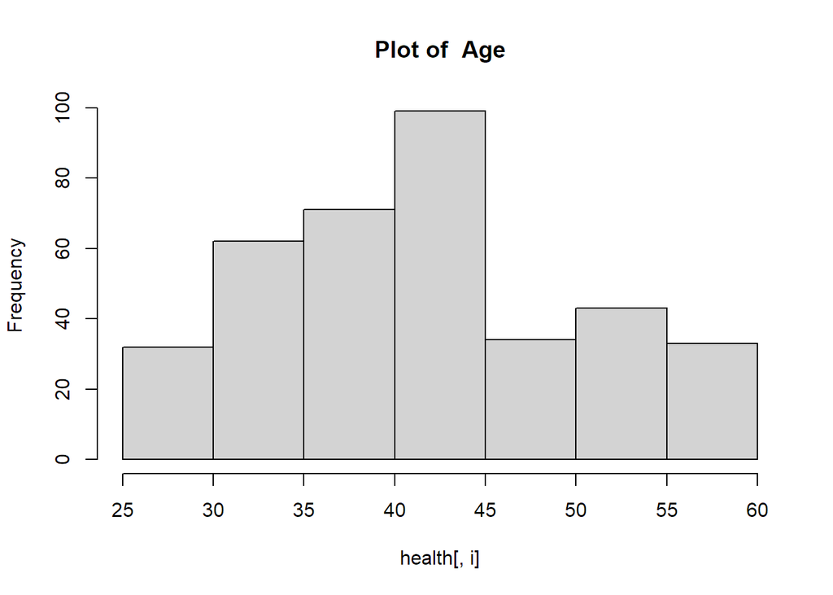

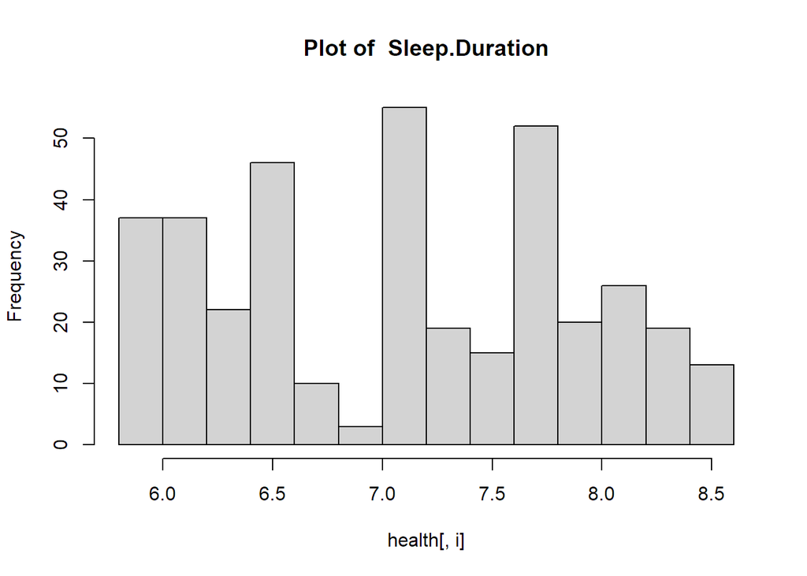

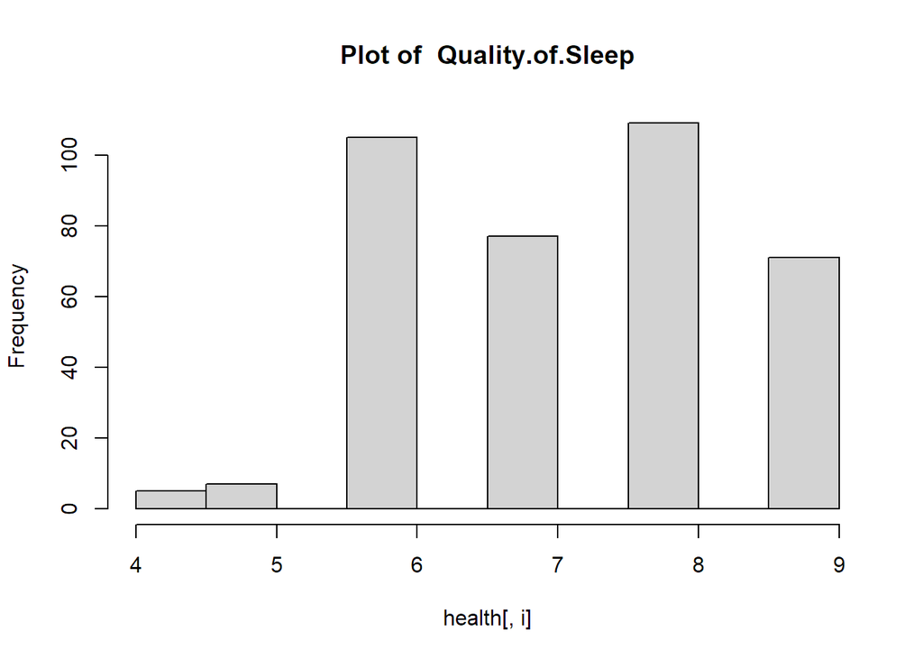

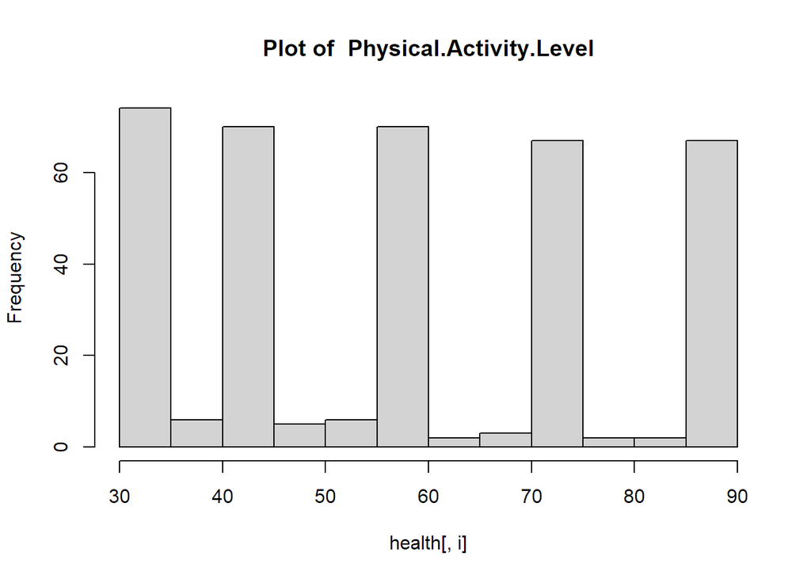

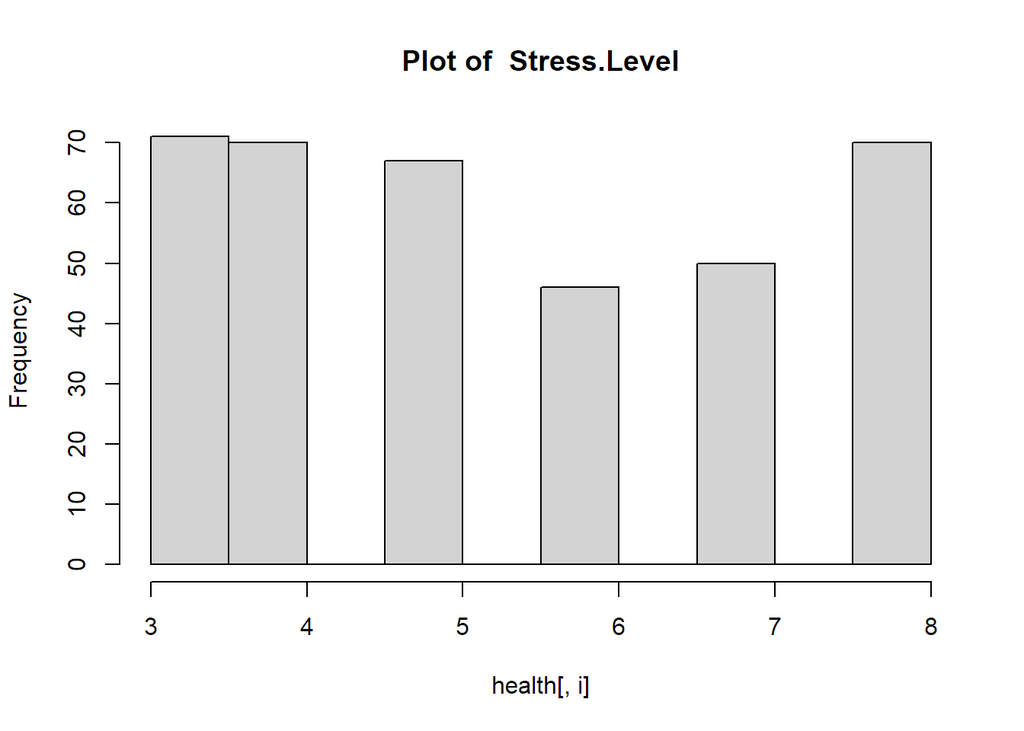

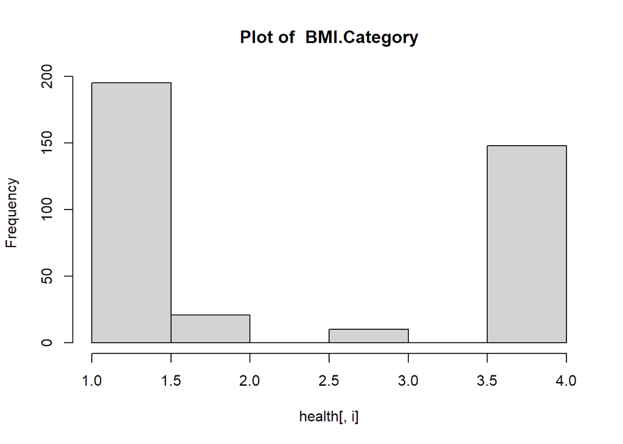

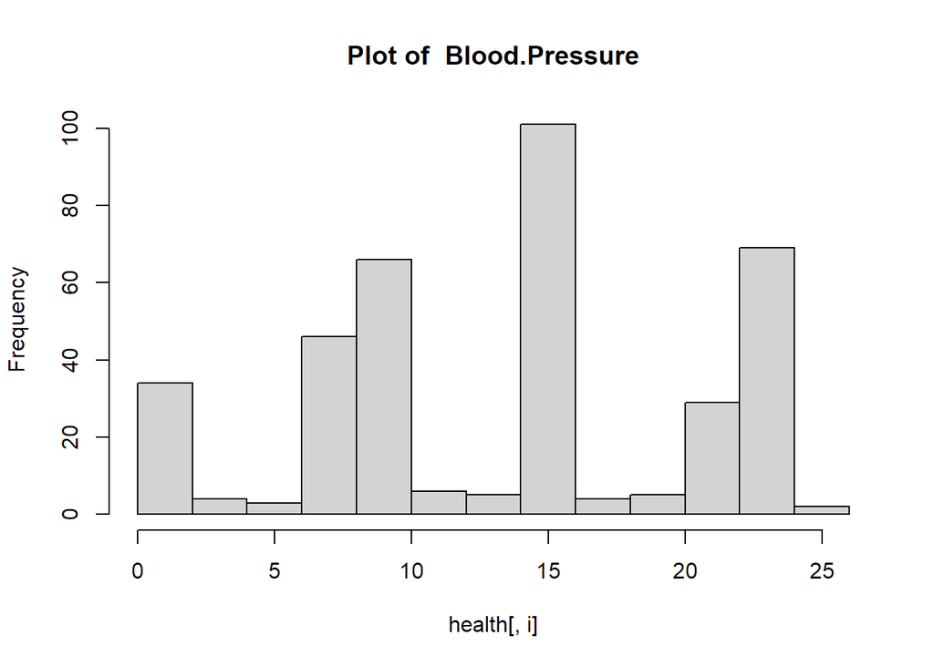

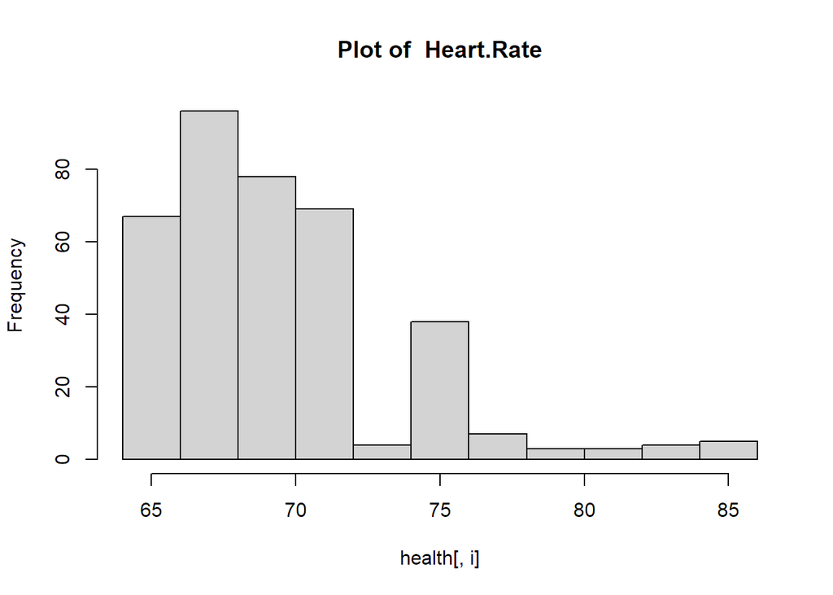

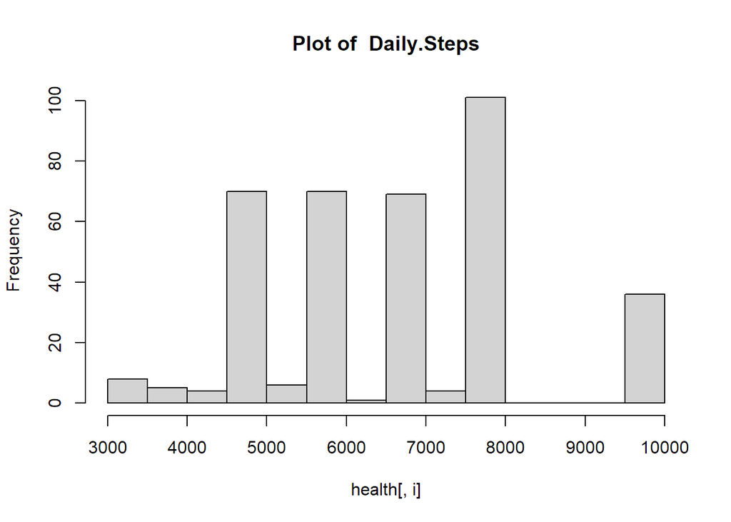

```r
for (i in colnames(health)) {
  hist(health[,i], main = paste("Plot of ", i))
}
```

Data plots looks good, we cant see anything unusual.

### Corelation matrix

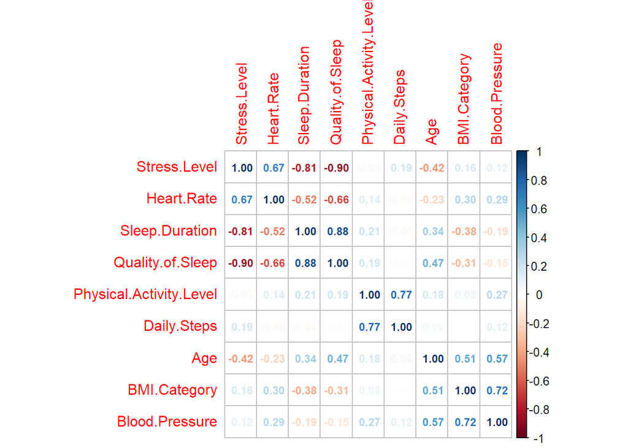

```r
health_matrix <- data.matrix(health, rownames.force = NA)
M <- cor(health_matrix)
corrplot(M, method = "number", number.cex = 0.75, order="hclust")
```

In the dataset, we observe some positively correlated variables. There is a high correlation between the quality of sleep and sleep duration, as well as between daily steps and physical activity level. Additionally, we can identify some negatively correlated variables, such as the quality of sleep and stress level, or stress level and sleep duration.

We won’t remove any of these variables because they contain valuable information. Deleting them from further analysis solely based on correlation levels might not be advisable.

### Scaling values

To effectively use clustering algorithms we need to scale our data. This process ensures that all variables contribute equally to the clustering analysis.

```r
#scaling values
health_scaled<-scale(health)
```

### Assessing Clustering Tendency

```
## $hopkins_stat
## [1] 0.958199
##
## $plot
```

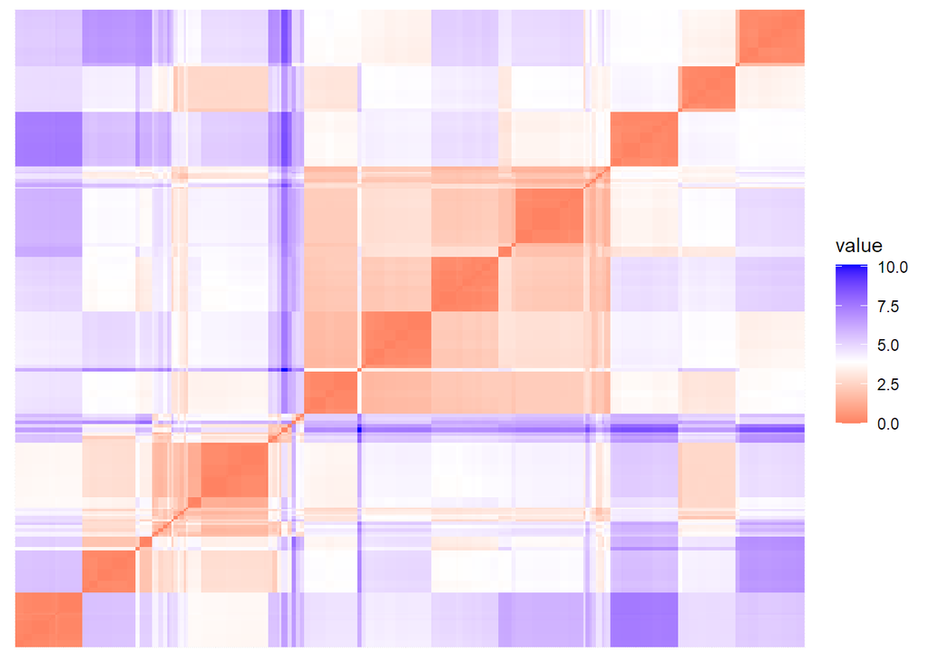

```r
get_clust_tendency(health_scaled, 2, graph=T)
```

Based on hpkins stat value which is above 0.95, we can assume that significant clusters exist.

## Clustering

### Optimal number of clusters

In this section focusing on clustering, we aim to identify the optimal number of clusters within the health dataset. We will evaluate the kmeans, pam, hcutwith silhouette method to determine the most suitable cluster configuration.

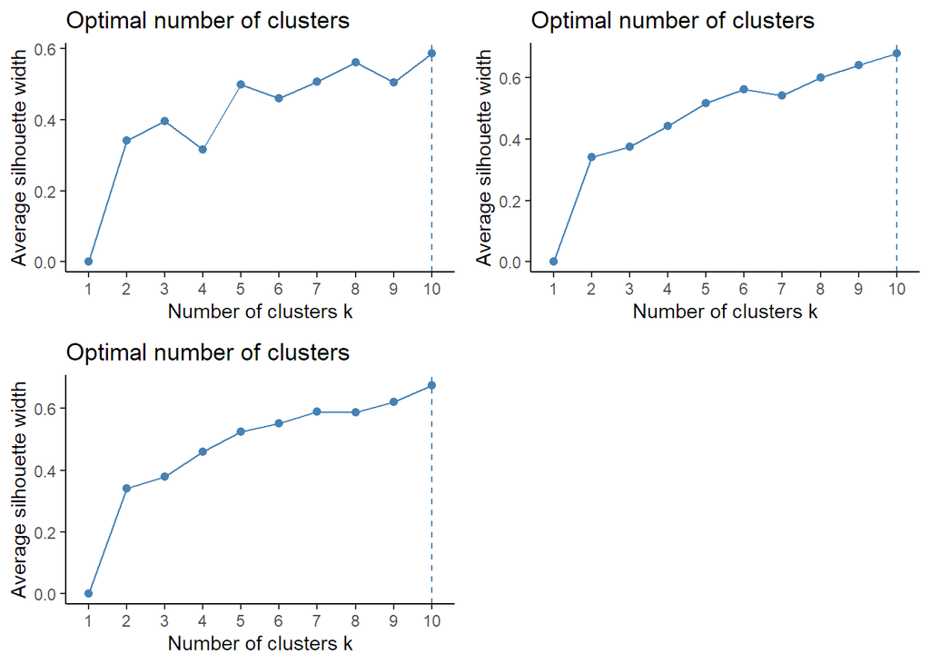

```r
grid.arrange(a, b, c, ncol=2)
```

### Using clustering algorithms

#### K-means

```r
health_clusters_kmeans_4<- kmeans(health_scaled, 4)
health_clusters_kmeans_6<- kmeans(health_scaled, 6)
```

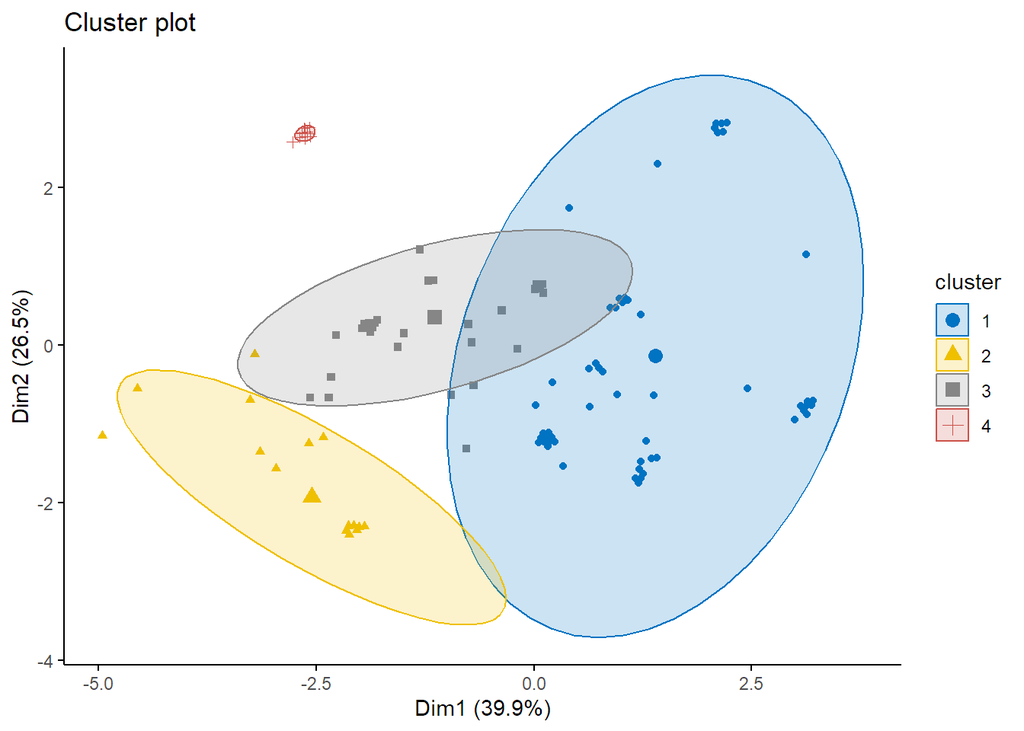

```r
fviz_cluster(list(data=health_scaled, cluster=health_clusters_kmeans_4$cluster),
             ellipse.type="norm", geom="point", stand=FALSE, palette="jco", ggtheme=theme_classic())
```

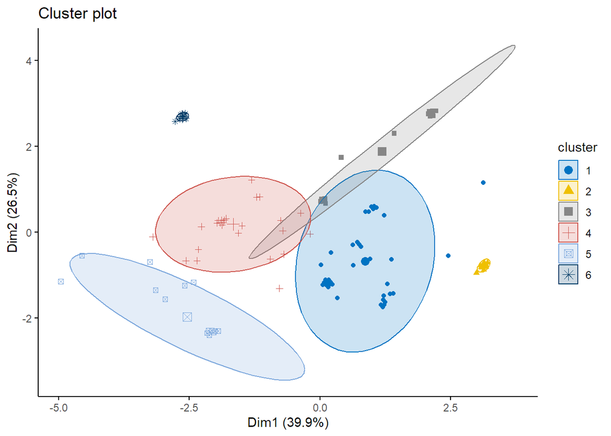

```r
fviz_cluster(list(data=health_scaled, cluster=health_clusters_kmeans_6$cluster),
             ellipse.type="norm", geom="point", stand=FALSE, palette="jco", ggtheme=theme_classic())
```

```
##   cluster size ave.sil.width
## 1       1  212          0.30
## 2       2   45          0.44
## 3       3   85          0.42
## 4       4   32          0.97
```

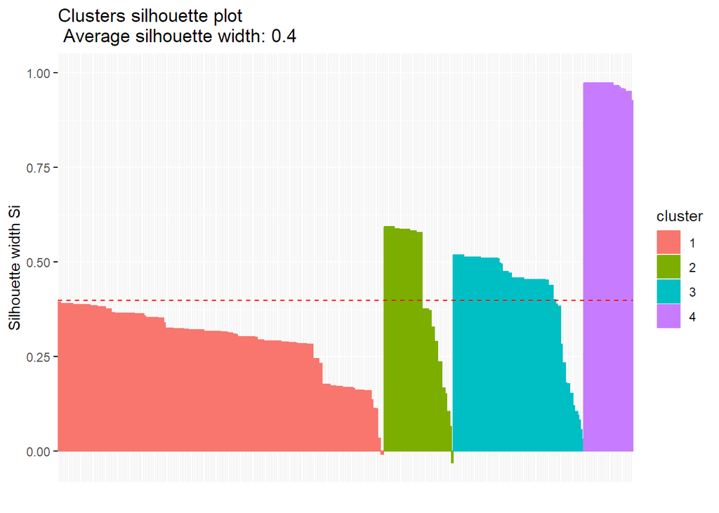

```r
sil<-silhouette(health_clusters_kmeans_4$cluster, dist(health_scaled))
fviz_silhouette(sil)
```

```
##   cluster size ave.sil.width
## 1       1  145          0.47
## 2       2   32          0.95
## 3       3   60          0.39
## 4       4   61          0.50
## 5       5   44          0.39
## 6       6   32          0.96
```

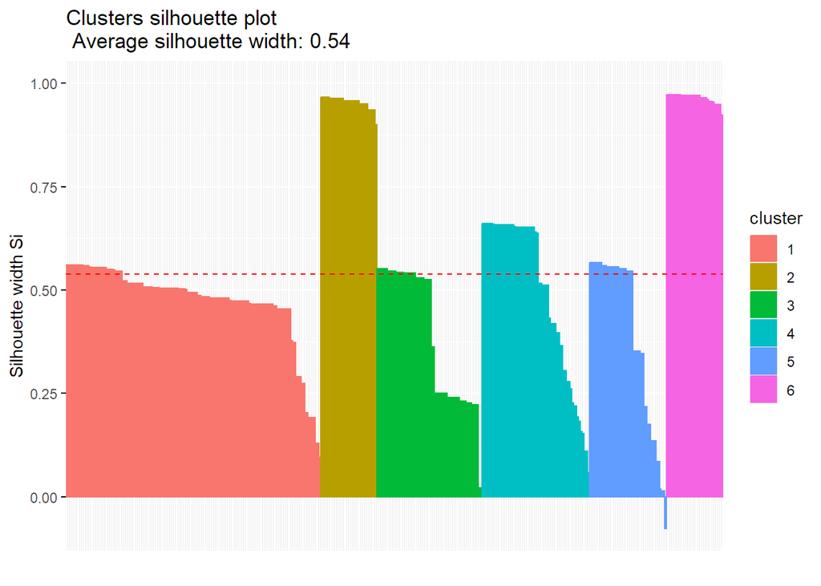

```r
sil<-silhouette(health_clusters_kmeans_6$cluster, dist(health_scaled))
fviz_silhouette(sil)
```

##### General characteristics of clusters

```r
health_clusters_kmeans_4$size
```

```
## [1] 212  45  85  32
```

```r
health_clusters_kmeans_4$cluster
```

```
##   1   2   3   4   5   6   7   8   9  10  11  12  13  14  15  16  17  18  19  20
##   2   2   2   2   2   2   2   1   1   1   2   1   2   2   2   2   2   2   2   1
##  21  22  23  24  25  26  27  28  29  30  31  32  33  34  35  36  37  38  39  40
##   1   1   1   1   1   1   1   1   1   1   2   2   1   2   1   2   2   1   1   1
##  41  42  43  44  45  46  47  48  49  50  51  52  53  54  55  56  57  58  59  60
##   1   1   1   1   1   1   1   1   1   1   1   1   2   1   2   2   1   2   2   1
##  61  62  63  64  65  66  67  68  69  70  71  72  73  74  75  76  77  78  79  80
##   2   2   2   2   2   2   1   2   3   3   2   2   2   2   2   2   2   2   2   2
##  81  82  83  84  85  86  87  88  89  90  91  92  93  94  95  96  97  98  99 100
##   2   2   3   3   1   1   1   1   1   1   1   1   1   3   1   1   1   1   1   1
## 101 102 103 104 105 106 107 108 109 110 111 112 113 114 115 116 117 118 119 120
##   1   1   1   3   1   3   3   1   1   1   1   1   1   1   1   1   1   1   1   1
## 121 122 123 124 125 126 127 128 129 130 131 132 133 134 135 136 137 138 139 140
##   1   1   1   1   1   1   1   1   1   1   1   1   1   1   1   1   1   1   1   1
## 141 142 143 144 145 146 147 148 149 150 151 152 153 154 155 156 157 158 159 160
```

[output cut: 23 more lines]

```r
health$cluster_kmeans_4<-health_clusters_kmeans_4$cluster

health_clusters_kmeans_6$size
```

```
## [1] 145  32  60  61  44  32
```

```r
health_clusters_kmeans_6$cluster
```

```
##   1   2   3   4   5   6   7   8   9  10  11  12  13  14  15  16  17  18  19  20
##   5   5   5   5   5   5   5   1   1   1   5   1   5   5   5   5   5   5   5   1
##  21  22  23  24  25  26  27  28  29  30  31  32  33  34  35  36  37  38  39  40
##   1   1   1   1   1   1   1   1   1   1   5   5   1   5   1   5   5   1   1   1
##  41  42  43  44  45  46  47  48  49  50  51  52  53  54  55  56  57  58  59  60
##   1   1   1   1   1   1   1   1   1   1   1   1   5   1   5   5   1   5   5   1
##  61  62  63  64  65  66  67  68  69  70  71  72  73  74  75  76  77  78  79  80
##   5   5   5   5   5   5   1   5   4   4   5   5   5   5   5   5   5   5   5   5
##  81  82  83  84  85  86  87  88  89  90  91  92  93  94  95  96  97  98  99 100
##   5   5   4   4   1   1   1   1   1   1   1   1   1   4   1   1   1   1   1   1
## 101 102 103 104 105 106 107 108 109 110 111 112 113 114 115 116 117 118 119 120
##   1   1   1   4   1   4   4   1   1   1   1   1   1   1   1   1   1   1   1   1
## 121 122 123 124 125 126 127 128 129 130 131 132 133 134 135 136 137 138 139 140
##   1   1   1   1   1   1   1   1   1   1   1   1   1   1   1   1   1   1   1   1
## 141 142 143 144 145 146 147 148 149 150 151 152 153 154 155 156 157 158 159 160
```

[output cut: 23 more lines]

```r
health$cluster_kmeans_6<-health_clusters_kmeans_6$cluster
```

```r
colnames(health)
```

```
##  [1] "Age"                     "Sleep.Duration"
##  [3] "Quality.of.Sleep"        "Physical.Activity.Level"
##  [5] "Stress.Level"            "BMI.Category"
##  [7] "Blood.Pressure"          "Heart.Rate"
##  [9] "Daily.Steps"             "cluster_kmeans_4"
## [11] "cluster_kmeans_6"
```

```r
for (i in colnames(subset(health, select = -c(cluster_kmeans_4,cluster_kmeans_6)))) {
  print(i)
  print(aggregate(health, health[[i]] ~ cluster_kmeans_4, mean))
}
```

```
## [1] "Age"
##   cluster_kmeans_4 health[[i]]
## 1                1    42.81604
## 2                2    31.17778
## 3                3    43.58824
## 4                4    49.75000
## [1] "Sleep.Duration"
##   cluster_kmeans_4 health[[i]]
## 1                1    7.735377
## 2                2    6.091111
## 3                3    6.580000
## 4                4    6.065625
## [1] "Quality.of.Sleep"
##   cluster_kmeans_4 health[[i]]
## 1                1    8.183962
```

[output cut: 39 more lines]

#### PAM

```r
health_clusters_pam_6<- pam(health_scaled, 6)
```

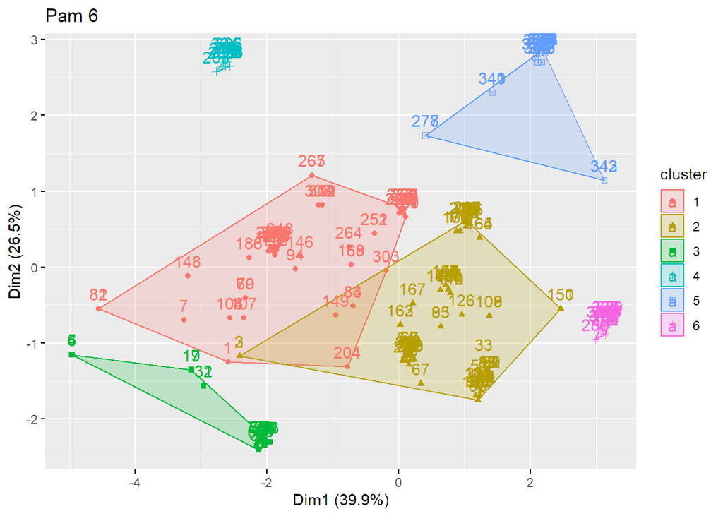

```r
fviz_cluster(health_clusters_pam_6,
             data = health_scaled,
             elipse.type = 'convex',
             main='Pam 6',
             show_labels = FALSE)
```

```
##   cluster size ave.sil.width
## 1       1   90          0.36
## 2       2  145          0.47
## 3       3   38          0.57
## 4       4   32          0.97
## 5       5   37          0.72
## 6       6   32          0.96
```

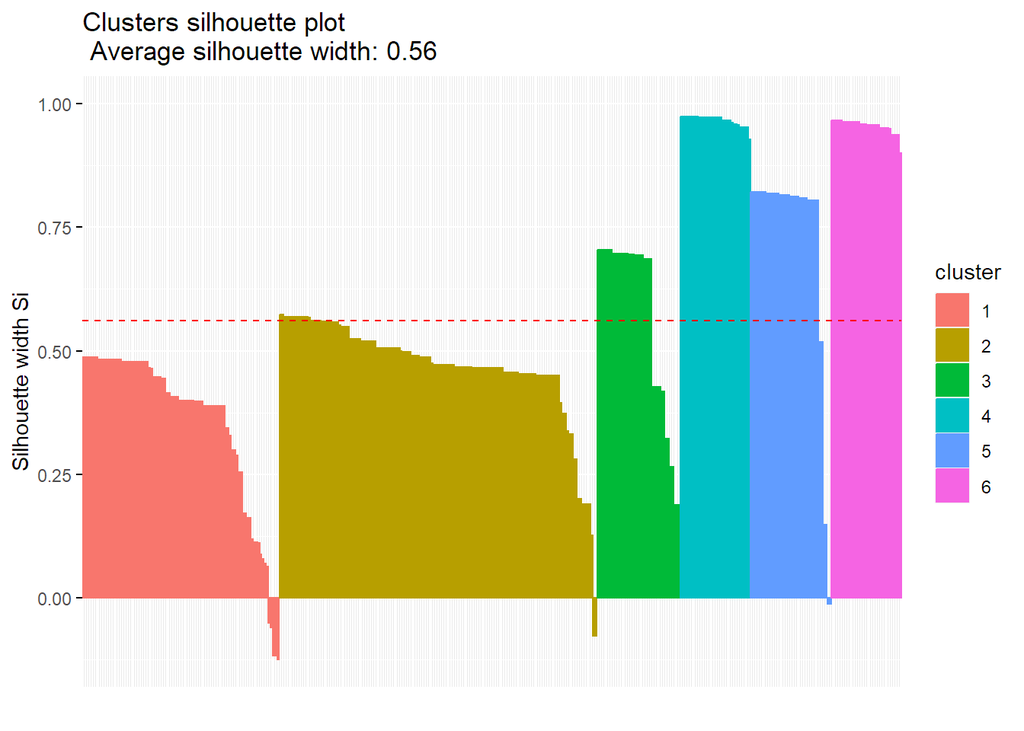

```r
fviz_silhouette(health_clusters_pam_6,ncol=2)
```

##### General characteristics of clusters

```r
health_clusters_pam_6$size
```

[output not shown]

```r
health_clusters_pam_6$cluster
```

```
##   1   2   3   4   5   6   7   8   9  10  11  12  13  14  15  16  17  18  19  20
##   1   2   2   3   3   3   1   2   2   2   3   2   3   3   3   3   3   3   3   2
##  21  22  23  24  25  26  27  28  29  30  31  32  33  34  35  36  37  38  39  40
##   2   2   2   2   2   2   2   2   2   2   3   3   2   3   2   3   3   2   2   2
##  41  42  43  44  45  46  47  48  49  50  51  52  53  54  55  56  57  58  59  60
##   2   2   2   2   2   2   2   2   2   2   2   2   3   2   3   3   2   3   3   2
##  61  62  63  64  65  66  67  68  69  70  71  72  73  74  75  76  77  78  79  80
##   3   3   3   3   3   3   2   3   1   1   3   3   3   3   3   3   3   3   3   3
##  81  82  83  84  85  86  87  88  89  90  91  92  93  94  95  96  97  98  99 100
##   1   1   1   1   2   2   2   2   2   2   2   2   2   1   2   2   2   2   2   2
## 101 102 103 104 105 106 107 108 109 110 111 112 113 114 115 116 117 118 119 120
##   2   2   2   1   2   1   1   2   2   2   2   2   2   2   2   2   2   2   2   2
## 121 122 123 124 125 126 127 128 129 130 131 132 133 134 135 136 137 138 139 140
##   2   2   2   2   2   2   2   2   2   2   2   2   2   2   2   2   2   2   2   2
## 141 142 143 144 145 146 147 148 149 150 151 152 153 154 155 156 157 158 159 160
```

[output cut: 23 more lines]

```r
health$cluster_pam_6<-health_clusters_pam_6$cluster
```

```r
colnames(health)
```

```
##  [1] "Age"                     "Sleep.Duration"
##  [3] "Quality.of.Sleep"        "Physical.Activity.Level"
##  [5] "Stress.Level"            "BMI.Category"
##  [7] "Blood.Pressure"          "Heart.Rate"
##  [9] "Daily.Steps"             "cluster_kmeans_4"
## [11] "cluster_kmeans_6"        "cluster_pam_6"
```

```r
for (i in colnames(subset(health, select = -c(cluster_kmeans_4,cluster_kmeans_6,cluster_pam_6)))) {
  print(i)
  print(aggregate(health, health[[i]] ~ cluster_pam_6, mean))
}
```

```
## [1] "Age"
##   cluster_pam_6 health[[i]]
## 1             1    42.97778
## 2             2    36.68276
## 3             3    31.15789
## 4             4    49.75000
## 5             5    57.43243
## 6             6    52.78125
## [1] "Sleep.Duration"
##   cluster_pam_6 health[[i]]
## 1             1    6.553333
## 2             2    7.468966
## 3             3    6.084211
## 4             4    6.065625
## 5             5    8.100000
```

[output cut: 57 more lines]

#### hierarchical

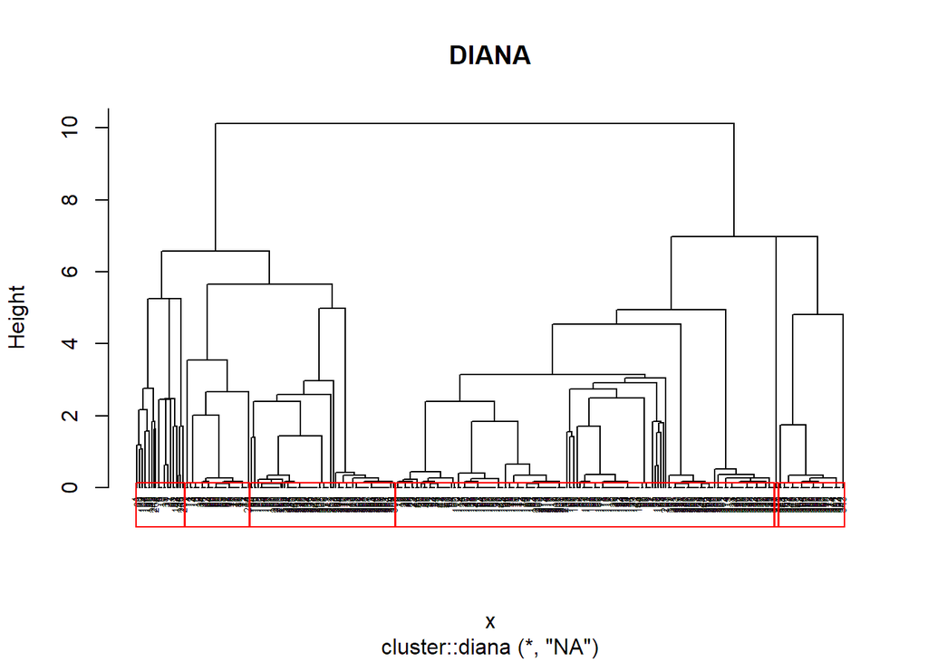

```r
health_clusters_diana <- eclust(health_scaled, k=6, FUNcluster = 'diana', hc_method = 'ward.D')
pltree(health_clusters_diana, hang = -1, main = "DIANA", cex = 0.47)
rect.hclust(health_clusters_diana, k=6, border='red')
```

```r
health_clusters_diana_stats <- cluster.stats(dist(health_scaled), health_clusters_diana$cluster)
health_clusters_diana_stats$avg.silwidth
```

```
## [1] 0.3831018
```

```r
health_clusters_diana_stats$cluster.size
```

```
## [1]  26  34 200  77   2  35
```

After testing k-means, PAM, and hierarchical clustering, the highest silhouette score among our attempts was achieved by PAM with 6 clusters.

```r
colnames(health)
```

```
##  [1] "Age"                     "Sleep.Duration"
##  [3] "Quality.of.Sleep"        "Physical.Activity.Level"
##  [5] "Stress.Level"            "BMI.Category"
##  [7] "Blood.Pressure"          "Heart.Rate"
##  [9] "Daily.Steps"             "cluster_kmeans_4"
## [11] "cluster_kmeans_6"        "cluster_pam_6"
```

```r
for (i in colnames(subset(health, select = -c(cluster_kmeans_4,cluster_kmeans_6,cluster_pam_6)))) {
  print(i)
  print(aggregate(health, health[[i]] ~ cluster_pam_6, mean))
}
```

```
## [1] "Age"
##   cluster_pam_6 health[[i]]
## 1             1    42.97778
## 2             2    36.68276
## 3             3    31.15789
## 4             4    49.75000
## 5             5    57.43243
## 6             6    52.78125
## [1] "Sleep.Duration"
##   cluster_pam_6 health[[i]]
## 1             1    6.553333
## 2             2    7.468966
## 3             3    6.084211
## 4             4    6.065625
## 5             5    8.100000
```

[output cut: 57 more lines]

```r
for (i in c(1:6) ){
  print(i)
  print(summary(health[health$cluster_pam_6 == i,1:9]))
}
```

```
## [1] 1
##       Age        Sleep.Duration  Quality.of.Sleep Physical.Activity.Level
##  Min.   :27.00   Min.   :5.800   Min.   :4.000    Min.   :30.00
##  1st Qu.:43.00   1st Qu.:6.400   1st Qu.:6.000    1st Qu.:45.00
##  Median :44.00   Median :6.500   Median :6.500    Median :45.00
##  Mean   :42.98   Mean   :6.553   Mean   :6.422    Mean   :45.28
##  3rd Qu.:44.75   3rd Qu.:6.600   3rd Qu.:7.000    3rd Qu.:45.00
##  Max.   :52.00   Max.   :7.400   Max.   :7.000    Max.   :65.00
##   Stress.Level    BMI.Category   Blood.Pressure    Heart.Rate     Daily.Steps
##  Min.   :4.000   Min.   :2.000   Min.   : 3.00   Min.   :65.00   Min.   :3300
##  1st Qu.:4.000   1st Qu.:4.000   1st Qu.:16.00   1st Qu.:65.00   1st Qu.:6000
##  Median :7.000   Median :4.000   Median :16.00   Median :72.00   Median :6000
##  Mean   :5.922   Mean   :3.878   Mean   :17.33   Mean   :71.24   Mean   :5694
##  3rd Qu.:7.000   3rd Qu.:4.000   3rd Qu.:21.00   3rd Qu.:72.00   3rd Qu.:6000
##  Max.   :8.000   Max.   :4.000   Max.   :25.00   Max.   :84.00   Max.   :6800
## [1] 2
##       Age        Sleep.Duration  Quality.of.Sleep Physical.Activity.Level
##  Min.   :28.00   Min.   :6.200   Min.   :6.000    Min.   :45.00
##  1st Qu.:32.00   1st Qu.:7.200   1st Qu.:8.000    1st Qu.:60.00
##  Median :37.00   Median :7.500   Median :8.000    Median :60.00
##  Mean   :36.68   Mean   :7.469   Mean   :7.766    Mean   :70.48
##  3rd Qu.:40.00   3rd Qu.:7.800   3rd Qu.:8.000    3rd Qu.:75.00
##  Max.   :43.00   Max.   :8.000   Max.   :9.000    Max.   :90.00
##   Stress.Level    BMI.Category   Blood.Pressure     Heart.Rate  Daily.Steps
##  Min.   :3.000   Min.   :1.000   Min.   : 1.000   Min.   :65   Min.   : 5000
##  1st Qu.:4.000   1st Qu.:1.000   1st Qu.: 6.000   1st Qu.:68   1st Qu.: 7000
##  Median :5.000   Median :1.000   Median : 7.000   Median :70   Median : 8000
##  Mean   :4.938   Mean   :1.103   Mean   : 9.338   Mean   :69   Mean   : 7617
##  3rd Qu.:6.000   3rd Qu.:1.000   3rd Qu.:16.000   3rd Qu.:70   3rd Qu.: 8000
##  Max.   :8.000   Max.   :4.000   Max.   :16.000   Max.   :75   Max.   :10000
## [1] 3
##       Age        Sleep.Duration  Quality.of.Sleep Physical.Activity.Level
##  Min.   :28.00   Min.   :5.900   Min.   :4.000    Min.   :30.00
##  1st Qu.:29.00   1st Qu.:6.000   1st Qu.:6.000    1st Qu.:30.00
##  Median :32.00   Median :6.000   Median :6.000    Median :30.00
##  Mean   :31.16   Mean   :6.084   Mean   :5.737    Mean   :30.79
##  3rd Qu.:33.00   3rd Qu.:6.100   3rd Qu.:6.000    3rd Qu.:30.00
##  Max.   :33.00   Max.   :6.500   Max.   :6.000    Max.   :40.00
##   Stress.Level    BMI.Category   Blood.Pressure    Heart.Rate     Daily.Steps
##  Min.   :7.000   Min.   :1.000   Min.   : 7.00   Min.   :70.00   Min.   :3000
```

[output cut: 42 more lines]

```
## [1] 6
##       Age        Sleep.Duration  Quality.of.Sleep Physical.Activity.Level
##  Min.   :50.00   Min.   :8.300   Min.   :9        Min.   :30
##  1st Qu.:52.75   1st Qu.:8.400   1st Qu.:9        1st Qu.:30
##  Median :53.00   Median :8.400   Median :9        Median :30
##  Mean   :52.78   Mean   :8.425   Mean   :9        Mean   :30
##  3rd Qu.:53.00   3rd Qu.:8.500   3rd Qu.:9        3rd Qu.:30
##  Max.   :54.00   Max.   :8.500   Max.   :9        Max.   :30
##   Stress.Level  BMI.Category Blood.Pressure   Heart.Rate  Daily.Steps
##  Min.   :3     Min.   :1     Min.   :10     Min.   :65   Min.   :5000
##  1st Qu.:3     1st Qu.:1     1st Qu.:10     1st Qu.:65   1st Qu.:5000
##  Median :3     Median :1     Median :10     Median :65   Median :5000
##  Mean   :3     Mean   :1     Mean   :10     Mean   :65   Mean   :5000
##  3rd Qu.:3     3rd Qu.:1     3rd Qu.:10     3rd Qu.:65   3rd Qu.:5000
##  Max.   :3     Max.   :1     Max.   :10     Max.   :65   Max.   :5000
```

Different clusters reveal variations in sleep patterns, physical activity levels, stress , daily steps, and BMI categories. Some individual has shorter but better quality sleep, with high physical activity levels and a constant stress level. Others have longer and more consistent sleep, maintaining lower stress levels and low physical activity levels.

## Conclusions

We successfully clustered health, sleep and lifestyle dataset using the PAM algorithm and validated it with the silhouette index. We gained valuable insights into the data, revealing notable differences between the clusters.